# Model 3: Mixed effects ordinal regression (stacked data)

## Model 1 (Most key predictors except for Frames)

Let’s start off with all the predictors with the exception of Frames (which we know drives everything). For the moment, we’ll use the Net Payer dummy.

#### Summary model 1

Given such a bare model, it’s not surprising that Level is important alongside some other story attributes such as word length and visibility.

```
Cumulative Link Mixed Model fitted with the Laplace approximation

formula:
europ2 ~ level + NetPayer + bad_thing17 + equi17 + vis4 + words +
    year2 + sourceFormat + (1 | country) + (1 | site)
data:    df

 link  threshold nobs logLik  AIC     niter      max.grad cond.H
 logit flexible  984  -952.81 1933.61 1360(4085) 8.11e-05 4.6e+03

Random effects:
 Groups  Name        Variance Std.Dev.
 site    (Intercept) 0.9444   0.9718
 country (Intercept) 0.3811   0.6173
Number of groups:  site 227,  country 8

Coefficients:
                        Estimate Std. Error z value Pr(>|z|)
levelNational            1.02063    0.22301   4.577 4.72e-06 ***
NetPayerYes              0.26693    0.73451   0.363   0.7163
bad_thing17             -1.70216    4.37890  -0.389   0.6975
equi17                   0.38726    0.36427   1.063   0.2877
vis4.L                   0.90384    0.13882   6.511 7.48e-11 ***
vis4.Q                  -0.07663    0.12077  -0.635   0.5258
words500-1000            0.30163    0.15687   1.923   0.0545 .
words+1000               0.64165    0.26895   2.386   0.0170 *
year2                    0.11902    0.10171   1.170   0.2419
sourceFormatOnline only -0.19274    0.22316  -0.864   0.3878
---
Signif. codes:  0 '***' 0.001 '**' 0.01 '*' 0.05 '.' 0.1 ' ' 1

Threshold coefficients:
            Estimate Std. Error z value
None|Medium  -0.1090     0.8334  -0.131
Medium|High   1.9352     0.8368   2.313
(1 observation deleted due to missingness)
```

## Model2 (Key predictors plus Frames)

#### Summary model 2

The Level predictor remains significant when Frames (dim) is included in the model.

```
Cumulative Link Mixed Model fitted with the Laplace approximation

formula: europ2 ~ dim + level + NetPayer + bad_thing17 + equi17 + vis4 +
    words + year2 + sourceFormat + (1 | country) + (1 | site)
data:    df

 link  threshold nobs logLik  AIC     niter      max.grad cond.H
 logit flexible  984  -928.43 1886.87 1533(4619) 2.29e-04 5.8e+03

Random effects:
 Groups  Name        Variance Std.Dev.
 site    (Intercept) 0.8168   0.9038
 country (Intercept) 0.5357   0.7319
Number of groups:  site 227,  country 8

Coefficients:
                        Estimate Std. Error z value Pr(>|z|)
dimPolitics              1.11208    0.16092   6.911 4.82e-12 ***
levelNational            0.83461    0.21774   3.833 0.000127 ***
NetPayerYes              0.16551    0.84404   0.196 0.844536
bad_thing17             -0.51277    5.03412  -0.102 0.918869
equi17                   0.31830    0.41739   0.763 0.445708
vis4.L                   0.64328    0.14206   4.528 5.95e-06 ***
vis4.Q                  -0.06722    0.12131  -0.554 0.579499
words500-1000            0.33107    0.15756   2.101 0.035619 *
words+1000               0.49159    0.26903   1.827 0.067661 .
year2                    0.08593    0.10164   0.845 0.397868
sourceFormatOnline only -0.12926    0.21638  -0.597 0.550256
---
Signif. codes:  0 '***' 0.001 '**' 0.01 '*' 0.05 '.' 0.1 ' ' 1

Threshold coefficients:
            Estimate Std. Error z value
None|Medium   0.3402     0.9449   0.360
Medium|High   2.4529     0.9495   2.583
(1 observation deleted due to missingness)
```

## Model 3 (Key predictors with interactions)

Let’s now add interaction effects across some of our key features.

#### Summary model 3

Adding the interactions, suggest only 1 of our core variables are signficant: Level.

```
Cumulative Link Mixed Model fitted with the Laplace approximation

formula:
europ2 ~ dim * (level + NetPayer + bad_thing17 + equi17) + vis4 +
    words + year2 + sourceFormat + (1 | country) + (1 | site)
data:    df

 link  threshold nobs logLik  AIC     niter      max.grad cond.H
 logit flexible  984  -925.30 1888.61 2478(7438) 3.24e-04 6.7e+03

Random effects:
 Groups  Name        Variance Std.Dev.
 site    (Intercept) 0.7962   0.8923
 country (Intercept) 0.5438   0.7374
Number of groups:  site 227,  country 8

Coefficients:
                          Estimate Std. Error z value Pr(>|z|)
dimPolitics                2.27400    0.56592   4.018 5.86e-05 ***
levelNational              1.10965    0.25399   4.369 1.25e-05 ***
NetPayerYes                0.29336    0.87144   0.337   0.7364
bad_thing17                1.18389    5.24864   0.226   0.8215
equi17                     0.29108    0.43128   0.675   0.4997
vis4.L                     0.62888    0.14273   4.406 1.05e-05 ***
vis4.Q                    -0.06489    0.12230  -0.531   0.5957
words500-1000              0.31760    0.15786   2.012   0.0442 *
words+1000                 0.44610    0.26960   1.655   0.0980 .
year2                      0.09302    0.10173   0.914   0.3605
sourceFormatOnline only   -0.15234    0.21601  -0.705   0.4807
dimPolitics:levelNational -0.70077    0.33496  -2.092   0.0364 *
dimPolitics:NetPayerYes   -0.21970    0.43625  -0.504   0.6145
dimPolitics:bad_thing17   -3.07816    2.75955  -1.115   0.2647
dimPolitics:equi17         0.01999    0.20228   0.099   0.9213
---
Signif. codes:  0 '***' 0.001 '**' 0.01 '*' 0.05 '.' 0.1 ' ' 1

Threshold coefficients:
            Estimate Std. Error z value
None|Medium   0.8891     0.9902   0.898
Medium|High   3.0035     0.9961   3.015
(1 observation deleted due to missingness)
```

## Model 4 (Optimal model)

Let’s now come up with an optimal model -having removed non-significant predictors.

#### Summary model 4

Here are the new coefficients for the optimal model.

```
Cumulative Link Mixed Model fitted with the Laplace approximation

formula: europ2 ~ dim * level + vis4 + words + (1 | country) + (1 | site)
data:    df

 link  threshold nobs logLik  AIC     niter     max.grad cond.H
 logit flexible  984  -927.80 1877.60 775(3001) 8.51e-04 7.1e+01

Random effects:
 Groups  Name        Variance Std.Dev.
 site    (Intercept) 0.8036   0.8964
 country (Intercept) 0.7188   0.8478
Number of groups:  site 227,  country 8

Coefficients:
                          Estimate Std. Error z value Pr(>|z|)
dimPolitics                1.63479    0.29033   5.631 1.79e-08 ***
levelNational              1.06785    0.25043   4.264 2.01e-05 ***
vis4.L                     0.61374    0.14150   4.337 1.44e-05 ***
vis4.Q                    -0.06638    0.12117  -0.548   0.5838
words500-1000              0.32412    0.15759   2.057   0.0397 *
words+1000                 0.45139    0.26853   1.681   0.0928 .
dimPolitics:levelNational -0.68127    0.33116  -2.057   0.0397 *
---
Signif. codes:  0 '***' 0.001 '**' 0.01 '*' 0.05 '.' 0.1 ' ' 1

Threshold coefficients:
            Estimate Std. Error z value
None|Medium   0.3850     0.3650   1.055
Medium|High   2.4968     0.3761   6.639
(1 observation deleted due to missingness)
```

# Comparison of models

We can make a check between model 3 and 4 to make sure there is no difference. As expected there isn’t a significant difference between the two models. So we keep the simpler, optimal model 4. And base the rest of the analysis on this model.

```
## Likelihood ratio tests of cumulative link models:
##
##    formula:
## m4 europ2 ~ dim * level + vis4 + words + (1 | country) + (1 | site)
## m3 europ2 ~ dim * (level + NetPayer + bad_thing17 + equi17) + vis4 + words + year2 + sourceFormat + (1 | country) + (1 | site)
##    link: threshold:
## m4 logit flexible
## m3 logit flexible
##
##    no.par    AIC logLik LR.stat df Pr(>Chisq)
## m4     11 1877.6 -927.8
## m3     19 1888.6 -925.3  4.9951  8     0.7581
```

# Model 4: Plotting interactions

We will now plot the interactions. There was only 1 signficant interaction between “Level” and “Frames”.

*Note* In the panels of the plot 1= None (no europeanization)

2= Medium europeanization

3= High europeanization

#### Plotting results

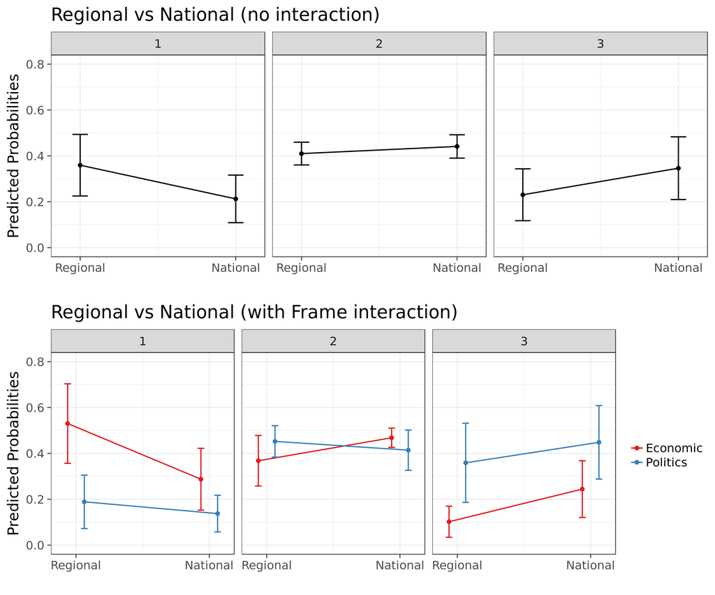

#### Substantive interpretation

A quick interpreation: The first plot shows that there is probably something going on between levels, but not very clear. The interaction plot shows how the Frame helps to understand what’s going on. Key differences:

1. None category (no Europeanization): Regional level sources much more likely to have no Europeanization in their stories, especially for Economic frame. This makes sense.
2. Medium Europeanisation: There is also something going on in the middle category; but not worth trying to interpret -although interesting because the lines cross with the interaction when compared to the non-interaction version. That’s why the non-interaction line is rather flat, because it masks the sublte differences related to the Frame.
3. High Europeanisation: National seems more likely to be Europeanized for Economics, less of change for Politics.